# Text analysis Part 1: Explanatory Data Analysis a.k.a EDA

This is the first part of my text analysis and my goal here is to explore dataset and get some insights from it before we dive to the deep end and use Machine Learning algorithms to analyse it. EDA is a crucial part after preprocessing the data in order to catch some weird things that may appear in the data. I'm using here the ham/spam dataset which consists of different text messages and labels that define if the messages are spam or decent mail. So let's get started!

First let's read in the data and activate some packages needed in this notebook. If you wanna run this on your own PC/notebook, make sure that it is in the same folder as this jupyter notebook. And if you don't have necessary R packages installed install them by using command install.packages() --> for example package dplyr;

```r
#install.packages('dplyr')
```

Now, let's get most of those needed packages:

```r
library(readr)
library(tm)
library(SnowballC)
library(MLmetrics)
library(dplyr)
library(stringr)
library(tidytext)
library(ggplot2)
library(Amelia)
library(wordcloud)
```

And now let's read in the data that is located in the same folder as this notebook, so that it is super easy to import:

```r
df <- read_csv("spam.csv")
df <- df[,1:2]

colnames(df) <- c("label", "msg") #Here we rename columns
df$label <- as.factor(df$label) #And here we convert label column to factor in order to categorize our data
```

Let's take a look how our labels are divided between spam emails and decent emails:

```r
library(repr)
options(repr.plot.width=5, repr.plot.height=4) #Here we make the plot smaller
```

```
 ham spam
4825  747
```

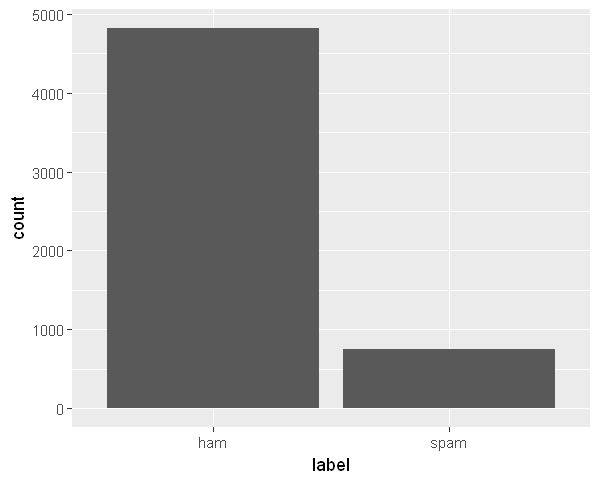

```r
table(df$label)
ggplot(df, aes(label)) + geom_bar()
```

Let's check if we have any missing values:

```r
sum(is.na(df))
```

0

No missing data, great! Now we can move on to preprocessing the data

## Data Preprocessing

First let's fix the encoding and after that we transform our msg-column to Vcorpus (collection of documents, in this case collection of all messages)

```r
df$msg <- str_replace_all(df$msg,"[^[:graph:]]", " ") #Fixes encoding
corpus = VCorpus(VectorSource(df$msg))
```

Then we process the corpus so that we transform all letters in messages to lowercase, remove numbers and punctuation, remove common stopwords in english, stem documents and lastly we strip whitespaces

```r
corpus = tm_map(corpus, content_transformer(tolower)) #All letters to lowercase
corpus = tm_map(corpus, removeNumbers) #Numbers off
corpus = tm_map(corpus, removePunctuation) #Remove punctuation
corpus = tm_map(corpus, removeWords, stopwords()) #Remove stopwords (default in english)
corpus = tm_map(corpus, stemDocument) #Stem words -->
corpus = tm_map(corpus, stripWhitespace) #Remove excessive whitespaces

as.character(corpus[[568]])
```

'anyway can just go gym whatev love smile hope ok good day babe miss much alreadi'

Okay, this is starting to look good! Next we transform our corpus to Document Term Matrix (DTM) which mean that every row is one document in corpus and columns are frequencies of words that appear in corpus documents.

```r
dtm = DocumentTermMatrix(corpus)
dtm = removeSparseTerms(dtm, 0.999) #Here we retain 99,9% of the most common words
dataset = as.data.frame(as.matrix(dtm)) #In order to fit model to this dataset we need to transform it to data frame

#Also let's add target labels to the data frame:

dataset$label = df$label
dataset$label = as.factor(df$label)
dim(dataset)
dataset <- dataset[,5:1202]
```

1. 5572

2. 1207

```r
head(dataset)
```

| abiola | abl | abt | accept | access | account | across | activ | actual | add | ... | yep | yes | yest | yesterday | yet | yiju | yoga | youd | youll | your |
| --- | --- | --- | --- | --- | --- | --- | --- | --- | --- | --- | --- | --- | --- | --- | --- | --- | --- | --- | --- | --- |
| 0 | 0 | 0 | 0 | 0 | 0 | 0 | 0 | 0 | 0 | ... | 0 | 0 | 0 | 0 | 0 | 0 | 0 | 0 | 0 | 0 |
| 0 | 0 | 0 | 0 | 0 | 0 | 0 | 0 | 0 | 0 | ... | 0 | 0 | 0 | 0 | 0 | 0 | 0 | 0 | 0 | 0 |
| 0 | 0 | 0 | 0 | 0 | 0 | 0 | 0 | 0 | 0 | ... | 0 | 0 | 0 | 0 | 0 | 0 | 0 | 0 | 0 | 0 |
| 0 | 0 | 0 | 0 | 0 | 0 | 0 | 0 | 0 | 0 | ... | 0 | 0 | 0 | 0 | 0 | 0 | 0 | 0 | 0 | 0 |
| 0 | 0 | 0 | 0 | 0 | 0 | 0 | 0 | 0 | 0 | ... | 0 | 0 | 0 | 0 | 0 | 0 | 0 | 0 | 0 | 0 |
| 0 | 0 | 0 | 0 | 0 | 0 | 0 | 0 | 0 | 0 | ... | 0 | 0 | 0 | 0 | 0 | 0 | 0 | 0 | 0 | 0 |

Next step is to separate words from each other and count how many times they appear in corpus (collection of all documents and in this case collection of all messages).

```r
msg_words <- df %>%
  unnest_tokens(word, msg) %>%
  count(label, word, sort=T) %>%
  ungroup()

head(msg_words)
```

| label | word | n |
| --- | --- | --- |
| ham | i | 2253 |
| ham | you | 1856 |
| ham | to | 1554 |
| ham | the | 1121 |
| ham | a | 1057 |
| ham | u | 1000 |

Here we see that our msg_words contains words, how many times they appeared in corpus (n) and corresponding label to that word. So label ham means that word with label ham most likely belong to class ham. Lets see how many words appeared in those ham/spam classes:

```r
msg_words_total <- msg_words %>%
  group_by(label) %>%
  summarize(total = sum(n))

head(msg_words_total)
```

| label | total |
| --- | --- |
| ham | 68602 |
| spam | 18440 |

Let's combine two previous dataframes:

```r
msg_words <- left_join(msg_words, msg_words_total)

head(msg_words)
```

| label | word | n | total |
| --- | --- | --- | --- |
| ham | i | 2253 | 68602 |
| ham | you | 1856 | 68602 |
| ham | to | 1554 | 68602 |
| ham | the | 1121 | 68602 |
| ham | a | 1057 | 68602 |
| ham | u | 1000 | 68602 |

Now it's time to plot our data. I'm using the allmighty ggplot2 to plot my figures. I'll start by plotting the graph that shows number of times a word appears in the spam or ham messages and divide that by the total number of words in ham or spam messages. Here we can see that these graphs have long tail which indicates that many words appear rarely and fewer words appear more frequently

```
Warning message:
"Removed 366 rows containing non-finite values (stat_bin)."
```

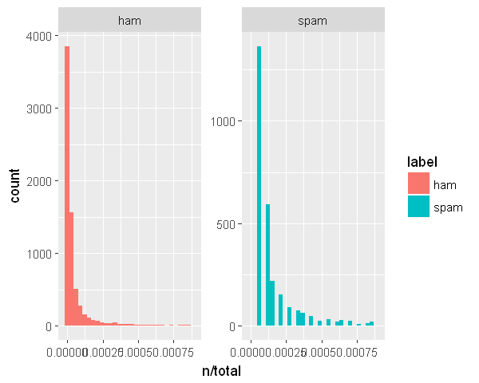

```r
ggplot(msg_words, aes(n/total, fill = label)) +
  geom_histogram(show.legend = T) +
  xlim(NA, 0.0009) +
  facet_wrap(~label, ncol = 2, scales = "free_y")
```

Now we are going to use TF-IDF in order to find the important words in each document. TF-IDF is weighted function, so that weight is decreased for words that appera commonly in corpus and weight in increased to words that appear rarely in corpus. This way we can find important words to our spam and ham mesages.

```r
msg_words <- msg_words %>%
  bind_tf_idf(word, label, n)

msg_words <- msg_words %>%
  select(-total) %>%
  arrange(desc(tf_idf))

head(msg_words)
```

| label | word | n | tf | idf | tf_idf |
| --- | --- | --- | --- | --- | --- |
| spam | claim | 113 | 0.006127983 | 0.6931472 | 0.004247594 |
| spam | prize | 92 | 0.004989154 | 0.6931472 | 0.003458218 |
| ham | gt | 318 | 0.004635433 | 0.6931472 | 0.003213038 |
| ham | lt | 316 | 0.004606280 | 0.6931472 | 0.003192830 |
| spam | won | 73 | 0.003958785 | 0.6931472 | 0.002744021 |
| spam | 150p | 71 | 0.003850325 | 0.6931472 | 0.002668842 |

Now let's plot this and see 15 most important words for each class (ham and spam):

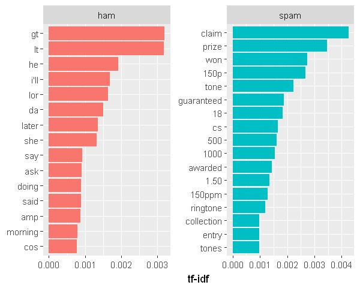

```r
tf_idf_plot <- msg_words %>%
  arrange(desc(tf_idf)) %>%
  mutate(word = factor(word, levels = rev(unique(word)))) %>%
  group_by(label) %>%
  top_n(15) %>%
  ungroup() %>%
  ggplot(aes(word, tf_idf, fill = label)) +
  geom_col(show.legend = FALSE) +
  labs(x = NULL, y = "tf-idf") +
  facet_wrap(~label, ncol = 2, scales = "free") +
  coord_flip()

tf_idf_plot
```

Now, a quick glance shows us that claim and prize are most important words in the spam class which is of course intuitive observation. There are many quite short words in the ham mesages but maybe they are some abbrevations of common english words (I'm from Finland, english isn't my native language). But let us proceed to the next step

## Create bigrams and visualize them

First we combine words that appear next to each other in texts and assign label to them

```r
msg_bigrams <- df %>%
  unnest_tokens(bigram, msg, token = "ngrams", n =2)

msg_bigrams %>%
  count(bigram, sort=T)
```

| bigram | n |
| --- | --- |
| lt gt | 276 |
| are you | 178 |
| i am | 140 |
| have a | 132 |
| you are | 129 |
| you have | 118 |
| do you | 109 |
| i will | 105 |
| in the | 99 |
| if you | 96 |
| i have | 88 |
| want to | 84 |
| to be | 83 |
| will be | 83 |
| i was | 81 |
| going to | 77 |
| in a | 76 |
| to get | 75 |
| this is | 73 |
| and i | 72 |
| but i | 72 |
| i can | 72 |
| have to | 70 |
| if u | 69 |
| on the | 66 |
| for the | 62 |
| you know | 61 |
| need to | 60 |
| you want | 60 |
| call me | 59 |
| ... | ... |
| yup hey | 1 |
| yup hopefully | 1 |
| yup how | 1 |
| yup i've | 1 |
| yup it's | 1 |
| yup izzit | 1 |
| yup leaving | 1 |
| yup n | 1 |
| yup next | 1 |
| yup not | 1 |
| yup song | 1 |
| yup thk | 1 |
| yup we | 1 |
| yup well | 1 |
| yup wun | 1 |
| yupz i've | 1 |
| z will | 1 |
| zac doesn't | 1 |
| zaher's i | 1 |
| zealand yes | 1 |
| zebra animation | 1 |
| zed pobox | 1 |
| zeros that | 1 |
| zhong se | 1 |
| zoe 18 | 1 |
| zoe it | 1 |
| zogtorius i | 1 |
| zoom to | 1 |
| zouk with | 1 |
| zyada kisi | 1 |

We need to activate few more libraries here:

```r
library(tidyr)
library(stopwords)
```

Let's filter out those stopwords, that are presented in stopwords-package:

```r
bigrams_separated <- msg_bigrams %>%
  separate(bigram, c("word1", "word2"), sep = " ")


bigrams_filtered <- bigrams_separated %>%
  filter(!word1 %in% stop_words$word) %>%
  filter(!word2 %in% stop_words$word)
```

Here we combine separate filtered word lists (for word1 and word2 lists).

```r
#New bigram counts:
bigram_counts <- bigrams_filtered %>%
  count(word1, word2, sort = T)

head(bigram_counts)

bigrams_united <- bigrams_filtered %>%
  unite(bigram, word1, word2, sep = " ")

head(bigrams_united)
```

| word1 | word2 | n |
| --- | --- | --- |
| lt | gt | 276 |
| wan | 2 | 26 |
| po | box | 25 |
| 1000 | cash | 23 |
| decimal | gt | 23 |
| guaranteed | call | 23 |

| label | bigram |
| --- | --- |
| ham | world la |
| ham | buffet cine |
| ham | amore wat |
| ham | lar joking |
| ham | joking wif |
| ham | aids patent |

Now we create Bag of Words model a.k.a TF-IDF matrix:

```r
#Bag of words model --> tf-idf:
bigram_tf_idf <- bigrams_united %>%
  count(label, bigram) %>%
  bind_tf_idf(bigram, label, n) %>%
  arrange(desc(tf_idf))

head(bigram_tf_idf)
```

| label | bigram | n | tf | idf | tf_idf |
| --- | --- | --- | --- | --- | --- |
| ham | lt gt | 276 | 0.026408956 | 0.6931472 | 0.018305293 |
| spam | 1000 cash | 23 | 0.003113578 | 0.6931472 | 0.002158168 |
| spam | guaranteed call | 23 | 0.003113578 | 0.6931472 | 0.002158168 |
| spam | prize guaranteed | 22 | 0.002978205 | 0.6931472 | 0.002064334 |
| spam | national rate | 20 | 0.002707459 | 0.6931472 | 0.001876668 |
| spam | await collection | 19 | 0.002572086 | 0.6931472 | 0.001782834 |

```r
library(igraph) #needed for visualization
```

Next we filter common combinations so that we see in our graphs only bigrams that appear more than 15 times in this corpus:

```r
#Filter common combinations:
bigram_graph <- bigram_counts %>%
  filter(n > 15) %>%
  graph_from_data_frame()
```

Let's plot this out, rough version:

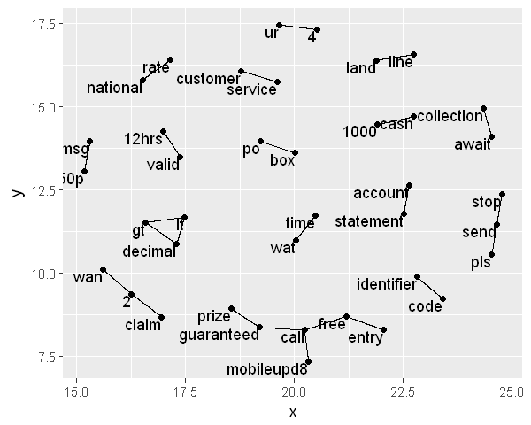

```r
set.seed(101)
ggraph(bigram_graph, layout = 'fr') +
  geom_edge_link() +
  geom_node_point() +
  geom_node_text(aes(label = name), vjust = 1, hjust = 1)
```

And more sophisticated version:

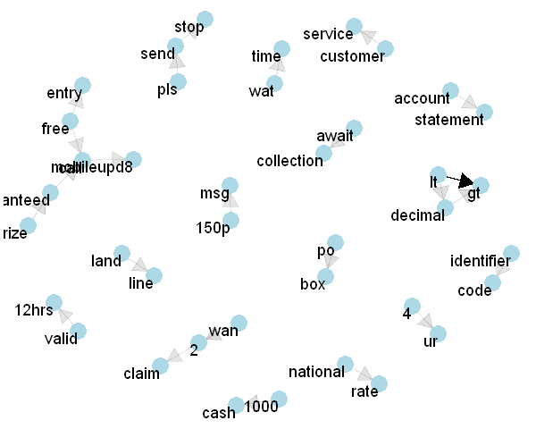

```r
set.seed(102)
a <- grid::arrow(type = "closed", length = unit(.15, "inches"))

ggraph(bigram_graph, layout = "fr") +
  geom_edge_link(aes(edge_alpha = n), show.legend = FALSE,
                 arrow = a, end_cap = circle(.07, 'inches')) +
  geom_node_point(color = "lightblue", size = 5) +
  geom_node_text(aes(label = name), vjust = 1, hjust = 1) +
  theme_void()
```

How to interpret this figure? Here we see the most common bigrams visualized. Arrow tell us how they appear in text; tip of the arrow points the the last word in bigrams. The darker the arrow is, more often bigram appears in corpus. For example lt gt is the most common bigram in this spam/ham dataset.

## Wordclouds for ham and spam messages

One great way to visually see immediately differences in words and their frequencies in different labels or classes is to use method called wordcloud. Wordclouds will show the most common words with bigger font and less frequent words with smaller font. This is a neat way to see quickly which words are common in different labels. This is fairly easy task to do:

```r
#First filter spam and ham messages to their own dataframes:
spam <- df %>%
  filter(df$label == "spam")

ham <- df %>%
  filter(df$label == "ham")
```

```r
library(repr)
options(repr.plot.width=7, repr.plot.height=5)
```

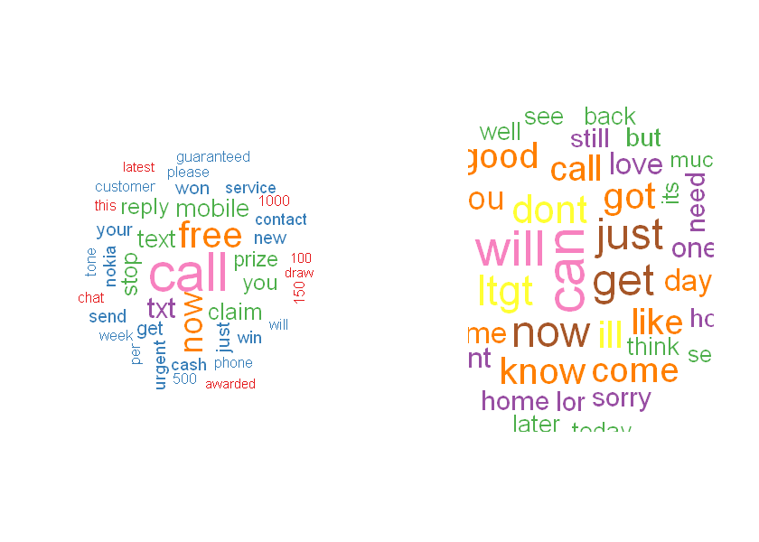

```r
#To make plots nicer, I will plot to graphs side by side:
par(mfrow=c(1,2))

#And here are the wordclouds:
wordcloud(spam$msg, max.words = 40, random.order = F, colors = brewer.pal(8, "Set1"), scale = c(3, 0.5))
wordcloud(ham$msg, max.words = 40, random.order = F, colors = brewer.pal(8, "Set1"),scale = c(3, 0.5))
```

## Thanks for following through this EDA section of text analysis. I hope you had fun and you learned something new along the way. Now go ahead and analyze your own datasets and have fun doing that!